# Preliminary EDA

Zoey Ye, Chanyong Song, Zifei Zheng

4/5/2020

## Front Matter

```r
# clean up the RStudio environment
rm(list = ls())
# load all packages here: `mosaic`, `tidyverse`, `lubridate`, and all others used
library(mosaic)
library(tidyverse)
library(lubridate)
library(ggplot2)
library(DataComputing)
```

We found COVID-19 in USA data source from kaggle as well. The data is obtained from COVID-19 Tracking project. The data focus mainly on the U.S. and provides details regarding 50 states and the District of Columbia at daily level. Each case represents the number of COVID 2019 patients in each state in the US daily. The data started from 3/4/2020 and currently have 1821 cases. We plan to use “Date”,“state”,“Positive”,“total”,and “deathIncrease”.

We also found ZipGeography data from DataComputing package. It has 42741 cases and each case represents Information about the location, area, and housing units in each ZIP code area. We plan to use some vraibles such as “State”,“Population”, and “County”.

- Two data sources

```r
covid <-
  read.csv('covid_19_data.csv')
covidUS <-
  covid %>%
  filter(Country.Region == "US")
covidUS
```

| SNo | ObservationDate | Province.State | Country.Region | Last.Update | Confirmed | Deaths | Recovered |
| --- | --- | --- | --- | --- | --- | --- | --- |
| 32 | 01/22/2020 | Washington | US | 1/22/2020 17:00 | 1 | 0 | 0 |
| 70 | 01/23/2020 | Washington | US | 1/23/20 17:00 | 1 | 0 | 0 |
| 118 | 01/24/2020 | Washington | US | 1/24/20 17:00 | 1 | 0 | 0 |
| 119 | 01/24/2020 | Chicago | US | 1/24/20 17:00 | 1 | 0 | 0 |
| 159 | 01/25/2020 | Washington | US | 1/25/20 17:00 | 1 | 0 | 0 |
| 160 | 01/25/2020 | Illinois | US | 1/25/20 17:00 | 1 | 0 | 0 |
| 203 | 01/26/2020 | Washington | US | 1/26/20 16:00 | 1 | 0 | 0 |
| 204 | 01/26/2020 | Illinois | US | 1/26/20 16:00 | 1 | 0 | 0 |
| 205 | 01/26/2020 | California | US | 1/26/20 16:00 | 2 | 0 | 0 |
| 206 | 01/26/2020 | Arizona | US | 1/26/20 16:00 | 1 | 0 | 0 |

[output cut: 990 more lines]

#### There are 3369 rows and 8 columns.

```r
Top10States <-
  covidUS %>%
  filter(ObservationDate == '04/21/2020') %>%
  group_by(Province.State) %>%
  summarise(confirmed = sum(Confirmed)) %>%
  arrange(desc(confirmed)) %>%
  head(10) %>%
  rename(State = Province.State)
Top10States
```

| State | confirmed |
| --- | --- |
| New York | 258361 |
| New Jersey | 92387 |
| Massachusetts | 41199 |
| California | 35465 |
| Pennsylvania | 35249 |
| Illinois | 33059 |
| Michigan | 32667 |
| Florida | 27869 |
| Louisiana | 24854 |
| Texas | 20574 |

[figure not shown]

```r
ggplot(data = covidUS, aes(x = Province.State, y = Confirmed)) +
  geom_point()  +
  labs(title = "")
```

#### The graph shows there is one state with considerable confirmed and several states with intermediate number of confirmed and other state with small number of confirmed

### World Recovery Rate in Countries.

```r
dim(covid) # shape
```

```
[1] 17372     8
```

```r
names(covid) # columns
```

```
[1] "SNo"             "ObservationDate" "Province.State"  "Country.Region"
[5] "Last.Update"     "Confirmed"       "Deaths"          "Recovered"
```

```r
max(covid$Deaths) # most death
```

```
[1] 24648
```

```r
max(covid$Recovered) # most recover
```

```
[1] 95200
```

```r
max(covid$Confirmed) # most affected
```

```
[1] 258361
```

```r
covid  %>%
  group_by(ObservationDate)  %>%
  summarize(total_count = max(Confirmed))
```

| ObservationDate | total_count |
| --- | --- |
| 01/22/2020 | 444 |
| 01/23/2020 | 444 |
| 01/24/2020 | 549 |
| 01/25/2020 | 761 |
| 01/26/2020 | 1058 |
| 01/27/2020 | 1423 |
| 01/28/2020 | 3554 |
| 01/29/2020 | 3554 |
| 01/30/2020 | 4903 |
| 01/31/2020 | 5806 |

[output cut: 81 more lines]

```r
covidtotal <-
  covid  %>%
  filter(ObservationDate %in%
           '04/21/2020')
dim(covidtotal)
```

```
[1] 323   8
```

```r
covid_country <- covidtotal  %>%
group_by(`Country.Region`)  %>%
summarize(total_death = sum(Deaths),
         total_recovered = sum(Recovered),
         total_confirmed = sum(Confirmed))  %>%
mutate(recovery_rate = round(total_recovered / total_confirmed,2))
```

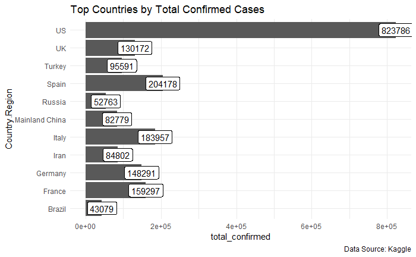

```r
covid_country  %>%
  filter(!`Country.Region` %in% 'Others')  %>%
  arrange(desc(total_confirmed))  %>%
  head(11)  %>%
  ggplot() + geom_bar(aes(`Country.Region`, total_confirmed), stat = "identity") +
  geom_label(aes(`Country.Region`, total_confirmed, label = total_confirmed)) +
  coord_flip() +
  theme_minimal() +
  labs(title =  "Top Countries by Total Confirmed Cases",
      caption = "Data Source: Kaggle")
```

[figure not shown]

```r
covid_country  %>%
  filter(!`Country.Region` %in% 'Others')  %>%
  filter(total_confirmed >= 10000) %>%
  arrange(desc(recovery_rate))  %>%
  head(11)  %>%
  ggplot() + geom_bar(aes(`Country.Region`, recovery_rate), stat = "identity") +
  geom_label(aes(`Country.Region`, recovery_rate, label = recovery_rate)) +
  coord_flip() +
  theme_minimal() +
  labs(title =  "Top Countries by Total Confirmed Cases",
      caption = "Data Source: Kaggle")
```

[figure not shown]

```r
covid_country  %>%
  filter(!`Country.Region` %in% 'Others')  %>%
  filter(total_confirmed >= 10000) %>%
  filter(recovery_rate != 0) %>%
  arrange(recovery_rate)  %>%
  head(11)  %>%
  ggplot() + geom_bar(aes(`Country.Region`, recovery_rate), stat = "identity") +
  geom_label(aes(`Country.Region`, recovery_rate, label = recovery_rate)) +
  coord_flip() +
  theme_minimal() +
  labs(title =  "Top Countries by Total Confirmed Cases",
      caption = "Data Source: Kaggle")
```